# Getting Started

Bo Burla

2025-03-19

`MiDAR` is an R package designed for the reproducible post-processing, quality control, and reporting of quantitative small-molecule mass spectrometry (MS) data. Its modular functionalities and defined data structure, support diverse analytical designs, data formats, and processing tasks, including metabolomics and lipidomics. `MiDAR` is intended for both analytical and bioinformatics scientists and to facilitate collaboration between them. It enables the creation of customizable, supervisable, and documented data processing workflows through intuitive high-level R functions and data objects.

`MiDAR`’s core tools, accessible also to those with limited R experience, allow analysts to annotate, inspect, and process data. This includes importing data and metadata from various file formats, managing and organizing data with integrity checks, performing processing tasks such as quantification, drift/batch correction, and applying QC-based feature filtering. Users can assess data quality using QC metrics and diagnostic plots, and share both raw and processed data along with the entire processing workflow for further analyses and documentation.

`MiDAR` also serves as a software library for building robust and scalable data processing pipelines.

## Getting Started

Visit the [MiDAR Documentation page (https://slinghub.github.io/midar)](https://slinghub.github.io/midar/) for a detailed introduction and comprehensive documentation on this package.

## Installation

```r
if (!require("pak")) install.packages("pak")
pak::pkg_install("SLINGhub/midar")
```

## Example Workflow

```r
# Path of example files included with this package
dir_path <- system.file("extdata",  package = "midar")

# Create a MidarExperiment object
mexp <- MidarExperiment()

# Load data and metadata
mexp <- import_data_mrmkit(mexp,
                           path = file.path(dir_path, "MRMkit_demo.tsv"),
                           import_metadata = TRUE)
```

```
#> ✔ Imported 499 analyses with 28 features
#> ℹ `feature_area` selected as default feature intensity. Modify with `set_intensity_var()`.
#> ✔ Analysis metadata associated with 499 analyses.
#> ✔ Feature metadata associated with 28 features.
```

```r
mexp <- import_metadata_analyses(mexp,
                                 path = file.path(dir_path, "MRMkit_AnalysesAnnot.csv"),
                                 ignore_warnings = T)
```

```
#> ✔ Analysis metadata associated with 499 analyses.
#> ✔ Feature metadata associated with 28 features.
```

```r
mexp <- import_metadata_istds(mexp,
                              path = file.path(dir_path, "MRMkit_ISTDconc.csv"))
```

```
#> ✔ Analysis metadata associated with 499 analyses.
#> ✔ Feature metadata associated with 28 features.
#> ✔ Internal Standard metadata associated with 9 ISTDs.
```

```r
# Normalize and quantitate features by internal standards
mexp <- normalize_by_istd(mexp)
```

```
#> ✔ 19 features normalized with 9 ISTDs in 499 analyses.
```

```r
mexp <- quantify_by_istd(mexp)
```

```
#> ✔ 19 feature concentrations calculated based on 9 ISTDs and sample amounts of 499 analyses.
#> ℹ Concentrations are given in μmol/L.
```

```r
# Drift and batch-effect correction
mexp <- correct_drift_cubicspline(mexp, variable = "conc", ref_qc_types = "BQC")
```

[output not shown]

```r
mexp <- correct_batch_centering(mexp, variable = "conc", ref_qc_types = "BQC")
```

```
#> ℹ Adding batch correction on top of `conc` drift-correction.
#> ✔ Batch median-centering of 6 batches was applied to drift-corrected concentrations of all 19 features.
#> ℹ The median CV change of all features in study samples was 0.01% (range: -7.60% to 2.50%).  The median absolute CV of all features increased from 36.14% to 36.76%.
```

```
#> Generating plots (4 pages)...
```

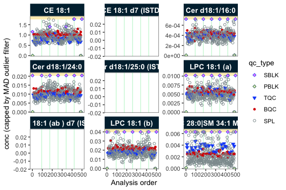

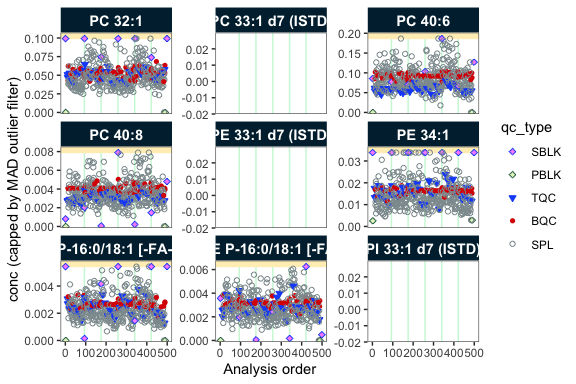

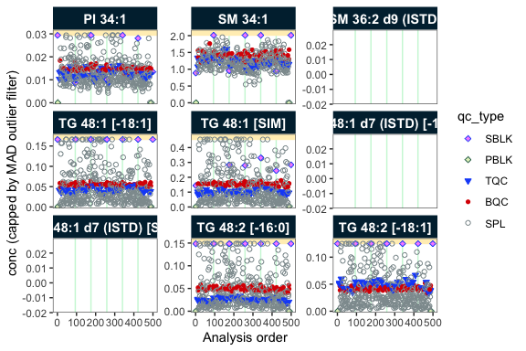

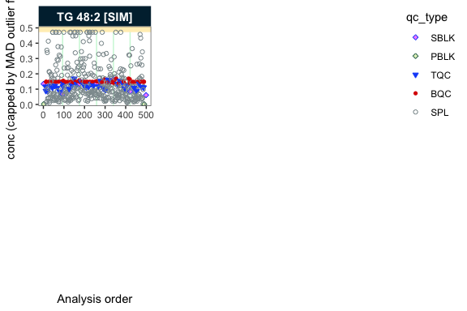

[output not shown]

```r
# Plot analysis time-trends of final concentrations of each feature
plot_runscatter(mexp,
                variable = "conc",
                qc_types = c("BQC", "TQC", "SPL", "PBLK", "SBLK"),
                cap_outliers = TRUE,
                output_pdf = FALSE,
                path = "./output/runscatter_istd.pdf")
```

## Contributor Code of Conduct

Please note that the midar project is released with a [Contributor Code of Conduct](https://contributor-covenant.org/version/2/0/CODE_OF_CONDUCT.html). By contributing to this project, you agree to abide by its terms.